# HarvardX Data Science Capstone 2 – Predicting Employee Attrition

Chengliang(Jake) Wu

2022-12-25

## 1. Introduction and Executive Summary

HR Analytics is defined as the [“collection and application of talent data to improve critical talent and business outcomes”](https://www.gartner.com/en/human-resources/glossary/hr-analytics). Examples include identifying models that predict amount of sick leaves taken, ascertaining links between employee engagement and business performance, and quantifying ROI on employee training. ([Source](https://www.aihr.com/blog/hr-analytics-case-studies/)). These practices allow for data-driven decision making in the HR function, a valuable capability that many companies are investing in now.

My second capstone project will be based in the HR Analytics domain. Specifically, I aim to: (1) Identify factors that correlate with employee attrition (i.e., voluntary departure of employees from an organization), and (2) Build and test a series of models that predict attrition. There is a case for studying this phenomenon: [Gallup](https://www.gallup.com/workplace/247391/fixable-problem-costs-businesses-trillion.aspx) estimates that the cost of replacing an employee ranges from 1.5-2 times an employee’s annual salary. It is clearly useful to identify and intervene on high-risk employees before actual attrition takes place.

I start by downloading the dataset.

```r
#Download IBM's HR Analytics Dataset#
#Source: https://www.kaggle.com/datasets/pavansubhasht/ibm-hr-analytics-attrition-dataset
temp <- tempfile(fileext = ".csv")
download.file("https://drive.google.com/u/0/uc?id=1MYrMS546iSBcps-1lkO0aHV-nVJn8htD&export=download",temp)
readfile <- read.csv(temp,quote="")
```

## 2. Methods and Analysis

The methods section is split into 4 parts: (1) Data observation, (2) Data Cleaning, (3) Pre-Processing, and (4) Exploration. Observation helps me make preliminary sense of the data, Cleaning removes ‘corrupt’ data that interferes with analysis, Pre-processing parses the data into a usable format, and Exploration addresses Research Task 1.

### 2.1 Data Observation

I first present the dataset in a tabular form for a quick visualization.

```r
#make sense of the overall data
as_tibble(readfile)
```

```
## # A tibble: 1,470 × 35
##      Age Attrition BusinessTravel    DailyRate Department       DistanceFromHome
##    <int> <chr>     <chr>                 <int> <chr>                       <int>
##  1    41 Yes       Travel_Rarely          1102 Sales                           1
##  2    49 No        Travel_Frequently       279 Research & Deve…                8
##  3    37 Yes       Travel_Rarely          1373 Research & Deve…                2
##  4    33 No        Travel_Frequently      1392 Research & Deve…                3
##  5    27 No        Travel_Rarely           591 Research & Deve…                2
##  6    32 No        Travel_Frequently      1005 Research & Deve…                2
##  7    59 No        Travel_Rarely          1324 Research & Deve…                3
##  8    30 No        Travel_Rarely          1358 Research & Deve…               24
##  9    38 No        Travel_Frequently       216 Research & Deve…               23
## 10    36 No        Travel_Rarely          1299 Research & Deve…               27
## # … with 1,460 more rows, and 29 more variables: Education <int>,
## #   EducationField <chr>, EmployeeCount <int>, EmployeeNumber <int>,
## #   EnvironmentSatisfaction <int>, Gender <chr>, HourlyRate <int>,
## #   JobInvolvement <int>, JobLevel <int>, JobRole <chr>, JobSatisfaction <int>,
## #   MaritalStatus <chr>, MonthlyIncome <int>, MonthlyRate <int>,
## #   NumCompaniesWorked <int>, Over18 <chr>, OverTime <chr>,
## #   PercentSalaryHike <int>, PerformanceRating <int>, …
```

We see a table of 1,470 rows of employee data, with 35 columns. Let us dive further into each of these columns, understanding what properties each of them have.

```r
#delve into individual columns
str(readfile)
```

```
## 'data.frame':    1470 obs. of  35 variables:
##  $ Age                     : int  41 49 37 33 27 32 59 30 38 36 ...
##  $ Attrition               : chr  "Yes" "No" "Yes" "No" ...
##  $ BusinessTravel          : chr  "Travel_Rarely" "Travel_Frequently" "Travel_Rarely" "Travel_Frequently" ...
##  $ DailyRate               : int  1102 279 1373 1392 591 1005 1324 1358 216 1299 ...
##  $ Department              : chr  "Sales" "Research & Development" "Research & Development" "Research & Development" ...
##  $ DistanceFromHome        : int  1 8 2 3 2 2 3 24 23 27 ...
##  $ Education               : int  2 1 2 4 1 2 3 1 3 3 ...
##  $ EducationField          : chr  "Life Sciences" "Life Sciences" "Other" "Life Sciences" ...
##  $ EmployeeCount           : int  1 1 1 1 1 1 1 1 1 1 ...
##  $ EmployeeNumber          : int  1 2 4 5 7 8 10 11 12 13 ...
##  $ EnvironmentSatisfaction : int  2 3 4 4 1 4 3 4 4 3 ...
##  $ Gender                  : chr  "Female" "Male" "Male" "Female" ...
##  $ HourlyRate              : int  94 61 92 56 40 79 81 67 44 94 ...
##  $ JobInvolvement          : int  3 2 2 3 3 3 4 3 2 3 ...
```

[output cut: 21 more lines]

The ‘str’ command lets us see the data contained in each of the 35 columns. We see a wide variety of employee information, ranging from age, to income, to Job Role, presented in both text and numeric forms.

### 2.2 Data Cleaning

In Data Cleaning, I check for N/A values (i.e., missing/blank information in the data set) and possible duplicated rows, to ensure that I do not get any errors or misleading insights as I perform my analysis and modelling. I will first check for N/A values through the (is.na) function, which will report out on any N/A values observed.

```r
which(is.na(readfile))
```

```
## integer(0)
```

The output is integer(0), i.e., no blank/NA values. Let us spot for duplicate rows.

```r
sum(duplicated(readfile))
```

```
## [1] 0
```

There are no duplicate rows spotted; the data does not require further cleaning at this point in time.

### 2.3 Pre-Processing

#### 2.3.1 Creating Dummy Variables

To work on the data, I have to modify certain columns which are clearly not suited for mathematical processing. For instance, the Gender Column comprises of “Male” and “Female”, character strings which R won’t be able to interpret. As such, I will apply the following methods:

1. **Splitting multi-categorical data into dummy variables**. We have columns such as Job Role and Department, each of which possesses multiple values (e.g., Sales Rep, Human Resources, Director, etc.). To force them into a mathematically-processable format, I will create dummy variables for each of these individual values. For example, in the case of Job Role, I will create 1 new column called Job Role_Sales Rep, another called Job Role_Human Resource, and so on until all roles are covered. An employee who is a Sales Rep will have a value of ‘1’ inside the Sales Rep column, and a value of ‘0’ for all other Job Role columns. The converse holds true for a Human Resources employee.
2. **Converting ordinal variables into numerical equivalents**. Strictly applied only to the “Business Travel” column as there is an order of intensity for business travel (Non Travel, Rarely, Frequently). Specifically, I will re-level them as ‘0’, ‘1’ and ‘2’ respectively.
3. **Converting binary variables into numerical equivalents**. There are columns that can only hold 2 values such as Gender (M/F), Attrition (Y/N) and Overtime (Y/N). I will recode them as 0/1 (1 = Male, or Yes).

This image sums up the 3 steps I am trying to achieve. The code will not be shown here (it is quite dense!).

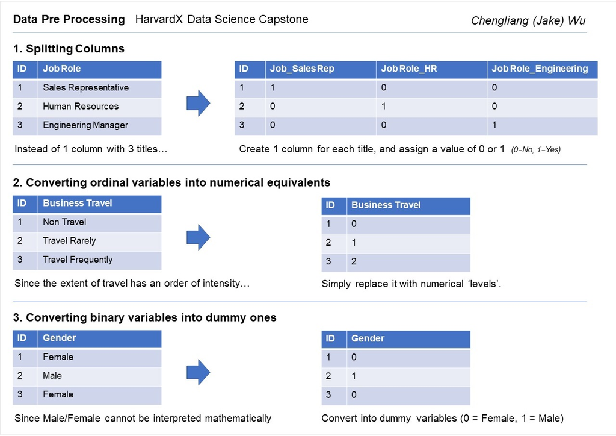

#### 2.3.2 Removing (near) zero variance predictors

By splitting data, I have just created many new columns, making analysis more cumbersome. To simplify, I will remove **near zero variance predictors** i.e., certain characteristics/predictors that are so uncommon that it is not meaningful to analyze the column itself. Removing such predictors can be done easily using the nearZeroVar function.

```r
#we have many variables, identify the near zero variance predictors using caret package's nearzerovar function
#<https://riptutorial.com/r/example/24920/removing-features-with-zero-or-near-zero-variance>
nearZeroVar(readfiletest1)
```

```
## [1]  7 18 23 33 44 47
```

The nearZerovar function identifies the column indices (i.e. numbers) to remove, and the subset function following it strips off these columns from our dataset.

```r
#remove those columns from the dataset
readfiletest2 <- subset(readfiletest1,select=-c(nearZeroVar(readfiletest1)))
```

We now have a parsimonious data set that we can finally get our hands on proper. I will split this dataset into training and test, at a 80:20 ratio. This is a rule of thumb espoused by [Roshan Joseph (2022)](https://onlinelibrary.wiley.com/doi/full/10.1002/sam.11583).

```r
# split data into training and test sets. I use a 80:20 split.
set.seed(1, sample.kind = "Rounding") # if using R 3.5 or earlier, remove the sample.kind argument
test_index <- createDataPartition(readfiletest2$Attrition, times = 1, p = 0.2, list = FALSE)
test_set <- readfiletest2[test_index, ]
train_set <- readfiletest2[-test_index, ]
```

### 2.3 Exploration

Putting aside the test set which is meant for its stated purpose, I will evaluate the training set to identify predictors that are (statistically-significantly) correlated with Attrition. This is done through a correlation plot - that basically evaluates pairwise correlations between every single column i.e., variable.

*Note that the concept of statistical significance will not be discussed here for parsimony.*

First, I need to remove highly-correlated variables, which do not add predictive power (and add modelling overheads).

```r
##### 2.3.1. Remove highly correlated variables
cor_mat<-cor(readfiletest2)
findCorrelation(cor_mat, .99)
```

```
## integer(0)
```

There are no highly correlated variables. Let us continue with the correlation plot.

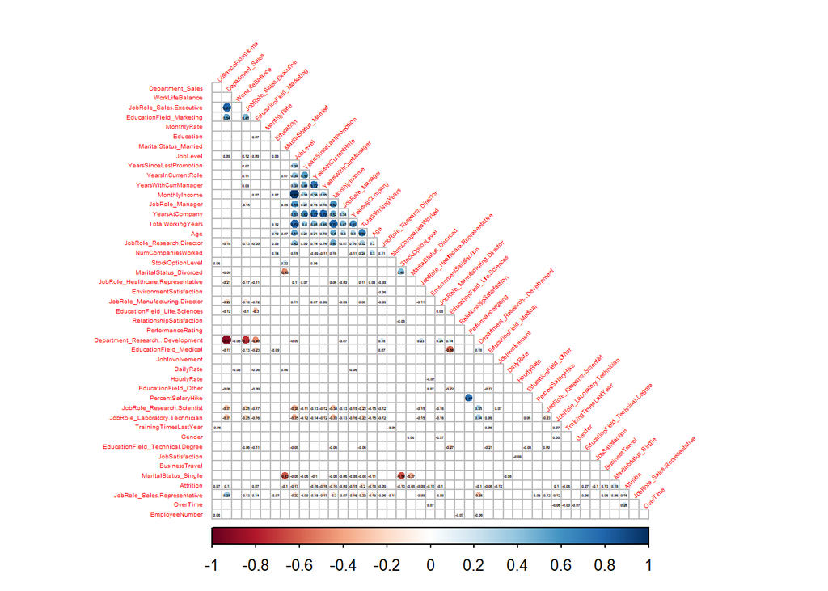

```r
##### 2.3.1. Remove non-significantly correlated variables (between attrition + predictor) #####

#First, generate correlation table with p-values below a certain value
testRes <- cor.mtest(train_set, conf.level = 0.95)

#Then, generate correlation plot
corrplot(cor(train_set), p.mat = testRes$p, method = 'circle', type = 'lower', insig='blank',
         addCoef.col ='black', number.cex = 0.2, order = 'AOE', diag=FALSE, tl.cex=0.3, tl.srt=45)
```

*Click on this link to view the Correlation Plot at full size.*

Zooming into the correlation plot above, we see that several columns a.k.a variables do not have a statistically-significant correlation with attrition. I will remove those variables prior to training our machine learning models, and re-run the correlation plot.

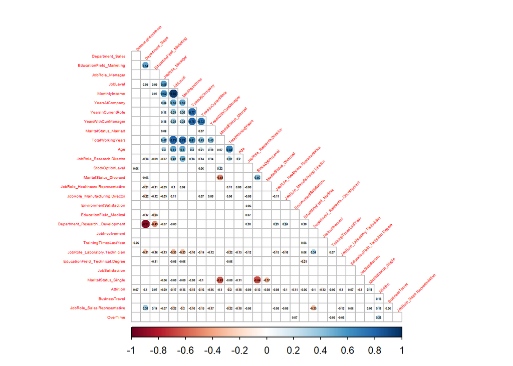

```r
#Identify column indices that have no relationship with attrition
#i.e. in the correlation table containing p-values, identify the 2nd row, which is attrition
#then, identify which column indices exceed the p-value of 0.05
remove_index <- which(((as.data.frame(testRes$p))[2,]) > 0.05)

#manually remove those columns that have no (statistically-significant) correlation with attrition
train_set_cleaned <- subset(train_set,select=-remove_index)

#generate correlation table once again with p-values below a certain value
testRes_cleaned <- cor.mtest(train_set_cleaned, conf.level = 0.95)

#generate correlation plot again, we should see a much cleaner table
corrplot(cor(train_set_cleaned), p.mat = testRes_cleaned$p, method = 'circle', type = 'lower', insig='blank',
         addCoef.col ='black', number.cex = 0.25, order = 'AOE', diag=FALSE, tl.cex=0.3, tl.srt=45)
```

Click on this link to view the Correlation Plot at full size. *(Notes: a higher value means a higher magnitude of correlation. a negative sign means a negative relationship i.e. higher the value of the variable, lower the attrition risk.)*

Notice that the correlation plot is simpler (i.e, fewer rows and columns) thanks to the removal of several variables that are not correlated with Attrition. Furthermore, the row with Attrition is now filled exclusively with significant correlations. This allows us to identify a few insights, thereby answering Research Task 1.

1. **What drives attrition?** Working overtime, being single, being a Sales Rep, being in the Sales department, and travelling a lot on business are factors associated with a higher rate of attrition.
2. **What else?** To a lesser extent, being situated far from home and being educated in marketing are also associated with a higher rate of attrition.
3. **On the flip side**, high job level, higher monthly income, being older, being married, and being in the role for a long time is associated with a lower rate of attrition.

Some of these points intuitively make sense, but it is important to acknowledge that these are but correlations, and not causal relationships. Working overtime does not necessarily cause attrition; there could be a background factor (e.g., an incompatible supervisor) that causes both overtime and attrition. Proving causal relationships requires actual experimentation.